# Introduction to Regular expressions

# 1 Introduction

Load packages:

```r
library(tidyverse)
library(stringr)
library(rtweet)
```

Resources used to create this lecture:

- https://evoldyn.gitlab.io/evomics-2018/ref-sheets/R_strings.pdf
- https://stat545.com/character-vectors.html#regular-expressions-with-stringr

## 1.1 Dataset we will use

We will be using Twitter data from the PAC-12 universities. This data was pulled from Twitter using the `rtweet` package. We will use the university admissions Twitter handle if there is one, or the main Twitter handle for the university if there isn’t one:

```r
#Code to pull data from Twitter
# library(rtweet)
#
# p12 <- c("uaadmissions", "FutureSunDevils", "caladmissions", "UCLAAdmission",
#          "futurebuffs", "uoregon", "BeaverVIP", "USCAdmission",
#          "engagestanford", "UtahAdmissions", "UW", "WSUPullman")
# p12_full_df <- search_tweets(paste0("from:", p12, collapse = " OR "), n = 500)
#
# saveRDS(p12_full_df, "p12_dataset.RDS")

# Load previously pulled Twitter data
# p12_full_df <- readRDS("p12_dataset.RDS")

p12_full_df <- readRDS(url("https://github.com/Rucla-ed/rclass2/raw/master/lectures/strings/p12_dataset.RDS", "rb"))
#glimpse(p12_full_df)

#Subset dataframe to a few variables
p12_df <- p12_full_df %>% select("user_id", "created_at", "screen_name", "text", "location")
head(p12_df)
```

```
## # A tibble: 6 x 5
##   user_id  created_at          screen_name text                     location
##   <chr>    <dttm>              <chr>       <chr>                    <chr>
## 1 22080148 2020-04-25 22:37:18 WSUPullman  "Big Dez is headed to I… Pullman, Wa…
## 2 22080148 2020-04-23 21:11:49 WSUPullman  "Cougar Cheese. That's … Pullman, Wa…
## 3 22080148 2020-04-21 04:00:00 WSUPullman  "Darien McLaughlin '19,… Pullman, Wa…
## 4 22080148 2020-04-24 03:00:00 WSUPullman  "6 houses, one pick. Co… Pullman, Wa…
## 5 22080148 2020-04-20 19:00:21 WSUPullman  "Why did you choose to … Pullman, Wa…
## 6 22080148 2020-04-20 02:20:01 WSUPullman  "Tell us one of your Br… Pullman, Wa…
```

## 1.2 Why use Regular Expressions (Regex)

[figure not shown]

*Credit: Regex Humor ([Rex Egg](https://www.rexegg.com/regex-humor.html))*

# 2 First things first

## 2.1 Special characters

Recall from the lecture on strings we talked about special characters and escape sequences.

> “A sequence in a string that starts with a `\` is called an **escape sequence** and allows us to include special characters in our strings.”

*Credit: [Escape sequences](https://campus.datacamp.com/courses/string-manipulation-with-stringr-in-r/string-basics?ex=4) from DataCamp*

Common **special characters**:

- `\'`: literal single quote
- `\"`: literal double quote
- `\\`: literal backslash
- `\n`: newline
- `\t`: tab

**The `writeLines()` function**:

```r
?writeLines

# SYNTAX AND DEFAULT VALUES
writeLines(text, con = stdout(), sep = "\n", useBytes = FALSE)
```

- “`writeLines()` displays quotes and backslashes as they would be read, rather than as R stores them.” (From writeLines documentation)
- When we include **escape sequences** in the string, it is helpful to use `writeLines()` to see how the escaped string looks
- `writeLines()` will also output the string without showing the outer pair of double quotes that R uses to store it, so we only see the content of the string

**Example**: Escaping backslashes**

```r
my_string <- "This backslash \\"
my_string
```

```
## [1] "This backslash \\"
```

Using `writeLines()` shows us only the content of the string without the second backslash:

```r
writeLines(my_string)
```

```
## This backslash \
```

**Example**: Escaping double quotes**

```r
my_string <- "I called my mom and she said \"Echale ganas!\""
my_string
```

```
## [1] "I called my mom and she said \"Echale ganas!\""
```

Using `writeLines()` shows us only the content of the string without the backslashes:

```r
writeLines(my_string)
```

```
## I called my mom and she said "Echale ganas!"
```

### 2.1.1 Escape special characters using Twitter data

Let’s take a look at some tweets from our PAC-12 universities.

- Let’s start by grabbing observations 1-3 from the `text` column.

```r
#Twitter example of \n newline special characters
p12_df$text[1:3]
```

```
## [1] "Big Dez is headed to Indy!\n\n#GoCougs | #NFLDraft2020 | @dadpat7 | @Colts | #NFLCougs https://t.co/NdGsvXnij7"
## [2] "Cougar Cheese. That's it. That's the tweet. \U0001f9c0#WSU #GoCougs https://t.co/0OWGvQlRZs"
## [3] "Darien McLaughlin '19, and her dog, Yuki, went on a #Pullman distance walk this weekend. We will let you judge who was leading the way.\U0001f6b6‍♀️\U0001f415\n\nTweet a pic of how you are social distancing w/ the hashtag #CougsContain &amp; tag @WSUPullman #GoCougs https://t.co/EltXDy1tPt"
```

- Using `writeLines()` we can see the contents of the strings as they would be read, rather than as R stores them.

```r
writeLines(p12_df$text[1:3])
```

```
## Big Dez is headed to Indy!
##
## #GoCougs | #NFLDraft2020 | @dadpat7 | @Colts | #NFLCougs https://t.co/NdGsvXnij7
## Cougar Cheese. That's it. That's the tweet. 🧀#WSU #GoCougs https://t.co/0OWGvQlRZs
## Darien McLaughlin '19, and her dog, Yuki, went on a #Pullman distance walk this weekend. We will let you judge who was leading the way.🚶‍♀️🐕
##
## Tweet a pic of how you are social distancing w/ the hashtag #CougsContain &amp; tag @WSUPullman #GoCougs https://t.co/EltXDy1tPt
```

**Example**: Escaping double quotes using Twitter data**

- Using Twitter data you may encounter a lot of strings with double quotes.
  - In the example below, our string includes special characters `\"` and `\n` to escape the double quotes and the newline character.

```r
#Twitter example of \" double quotes special characters
p12_df$text[24]
```

```
## [1] "\"I really am glad that inside Engineering Student Services, I’ve been able to connect with my ESS advisor and professional development advisors there.\"\n-Alexandro Garcia, Civil &amp; Environmental Engineering, 3rd year\n#imaberkeleyengineer #iamberkeley #voicesofberkeleyengineering https:…
```

- Using `writeLines()` we can see the contents of the strings as they would be read, rather than as R stores them.
  - We no longer see the escaped characters `\"` or `\n`

```r
writeLines(p12_df$text[24])
```

```
## "I really am glad that inside Engineering Student Services, I’ve been able to connect with my ESS advisor and professional development advisors there."
## -Alexandro Garcia, Civil &amp; Environmental Engineering, 3rd year
## #imaberkeleyengineer #iamberkeley #voicesofberkeleyengineering https://t.co/ToVEynIUWH
```

## 2.2 Special characters in regular expressions

There are special characters in regular strings as we have seen above and there are also certain characters in regex that have a special meaning (table below).

> What if you really need the plus sign to be a literal plus sign and not a regex quantifier? You will need to escape it by prepending a backslash. But wait … there’s more! Before a regex is interpreted as a regular expression, it is also interpreted by R as a string. And backslash is used to escape there as well. So, in the end, you need to preprend two backslashes in order to match a literal plus sign in a regex.

*Credit: [Escaping sequences](https://stat545.com/character-vectors.html#escaping) from Stat 545*

| STRING *(type string that represents regex)* | REGEX *(to have this appear in your regex)* | MATCHES *(to match with this text)* |
| --- | --- | --- |
| `\\.` | `\.` | . |
| `\\"` | `\"` | " (double quote) |
| `\\'` | `\'` | ’ (single quote) |
| `\\!` | `\!` | ! |
| `\\?` | `\?` | ? |
| `\\\\` | `\\` | \ |
| `\\(` | `\(` | ( |
| `\\)` | `\)` | ) |
| `\\{` | `\{` | { |
| `\\}` | `\}` | } |
| `\\n` | `\n` | new line (return) |
| `\\t` | `\t` | tab |
| `\\s` | `\s` | any whitespace |
| `\\S` | `\S` | any non-whitespace |
| `\\d` | `\d` | any digit |
| `\\D` | `\D` | any non-digit |
| `\\w` | `\w` | any word character |
| `\\W` | `\W` | any non-word character |
| `\\b` | `\b` | word-boundary |
| `\\B` | `\B` | non-word-boundary |

*Credit: [Working with strings in stringr](https://evoldyn.gitlab.io/evomics-2018/ref-sheets/R_strings.pdf) Cheat sheet*

### 2.2.1 Escape special character backslashes

> If \ is used as an escape character in regular expressions, how do you match a literal \? Well you need to escape it, creating the regular expression \\. To create that regular expression, you need to use a string, which also needs to escape \ . That means to match a literal \ you need to write “\\\\” — you need four backslashes to match one!

*Credit: [R for Data Science](https://r4ds.had.co.nz/strings.html#basic-matches) Strings Chapter*

The character vector below has one, two, three, and four backslashes.

```r
backslash <- c("\ ","\\", "\\\ ", "\\\\")

backslash
```

```
## [1] " "    "\\"   "\\ "  "\\\\"
```

- Using `writeLines()` we can see view the contents of the strings.

```r
writeLines(backslash)
```

```
##
## \
## \
## \\
```

```r
text <- "This is a backslash \\"
str_view(string = text, pattern = "\\\\")
```

[interactive chart not shown]

### 2.2.2 `str_view` and `str_view_all`

```r
?str_view

# SYNTAX AND DEFAULT VALUES
str_view(string, pattern, match = NA)
str_view_all(string, pattern, match = NA)
```

- Function: `str_view` shows the first match of a regex pattern; `str_view_all` shows all the matches of a regex pattern.
- Arguments:
- `string`: Input vector. Either a character vector, or something coercible to one.
- `pattern`: Pattern to look for.
  - The default interpretation is a regular expression, as described in stringi::stringi-search-regex. Control options with regex().
- `match`: If TRUE, shows only strings that match the pattern. If FALSE, shows only the strings that don’t match the pattern. Otherwise (the default, NA) displays both matches and non-matches.

`str_view` will show us the first regex pattern match

```r
str_view(string = p12_df$text[119], pattern = ('\\"'))
```

[interactive chart not shown]

Notice how we can see all the regex pattern matches with `str_view_all`

```r
str_view_all(string = p12_df$text[119], pattern = ('\\"'))
```

[interactive chart not shown]

**Example**: `str_view` & `str_view_all` regex for newline**

```r
str_view_all(string = p12_df$text[119], pattern = ("\\n"))
```

[interactive chart not shown]

**Example**: `str_view` & `str_view_all` regex for period**

```r
str_view_all(string = p12_df$text[119], pattern = ("\\."))
```

[interactive chart not shown]

**Example**: `str_view` & `str_view_all` regex for white space**

```r
str_view_all(string = p12_df$text[119], pattern = ("\\s"))
```

[interactive chart not shown]

**Example**: `str_view` & `str_view_all` regex for word bound**

```r
str_view_all(string = p12_df$text[119], pattern = ("\\b"))
```

[interactive chart not shown]

**Example**: `str_view` & `str_view_all` regex for digit(s)**

```r
str_view_all(string = p12_df$text[119], pattern = ("\\d"))
```

[interactive chart not shown]

## 2.3 RegExplain Addin

> Regular expressions are tricky. RegExplain makes it easier to see what you’re doing.

RegExplain is an RStudio addin that allows the user to check their regex matching functions interactively.

*Credit: Garrick Aden-Buie ([RegExplain](https://www.garrickadenbuie.com/project/regexplain/))*

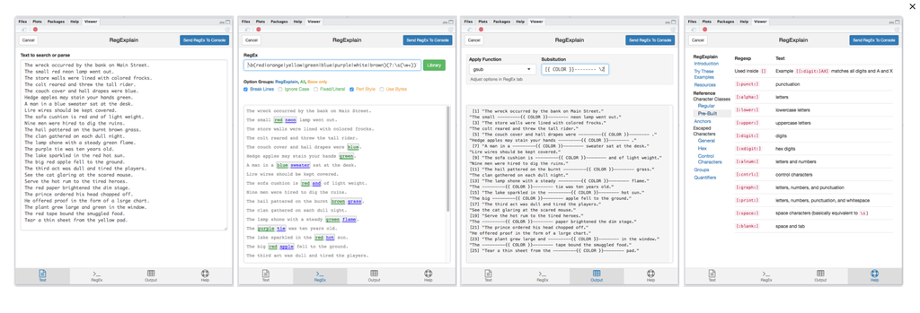

Installation

```r
devtools::install_github("gadenbuie/regexplain")
library(regexplain)
```

# 3 What are regular expressions?

What are regular expressions? from [Geeks for Geeks](https://www.geeksforgeeks.org/write-regular-expressions/)

- Regular expressions are “a sequence of characters that define a search pattern” similar to the [command + f] function you use to find text in a pdf or word document.

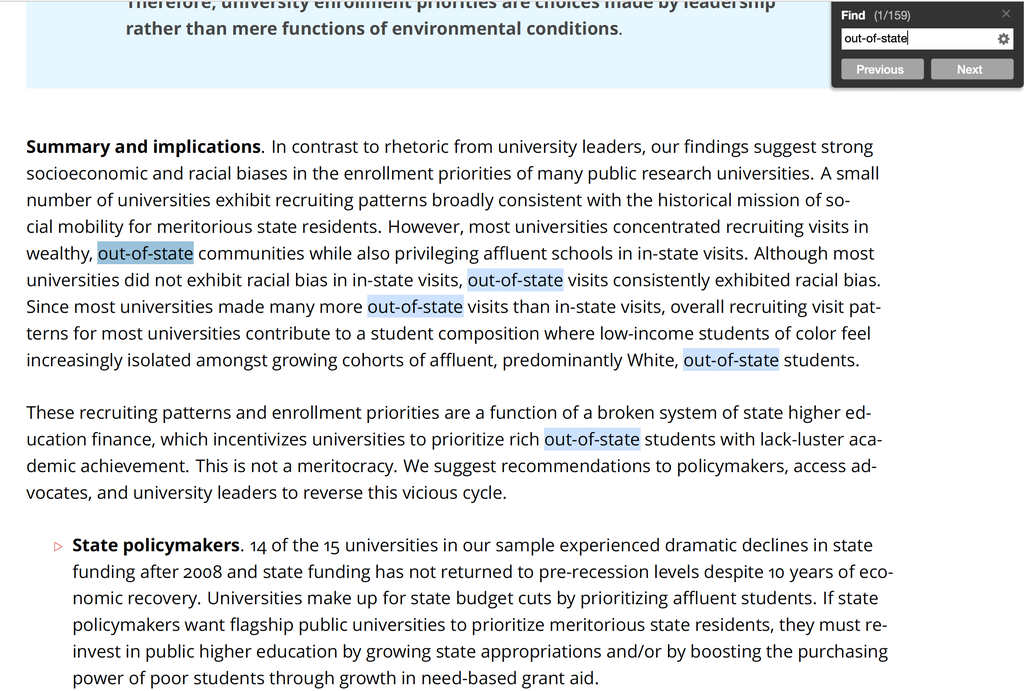

*Credit: Crystal Han, Ozan Jaquette, & Karina Salazar ([Recruiting the Out-Of-State University](https://emraresearch.org/sites/default/files/2019-03/joyce_report.pdf))*

- You could think of regular expressions like playing a game of charades. Assume a player grabs a playing card with an image of a person reading a book. Their task is to pantomine this action (reading a book) so that other players can guess what they are doing. Through the use of physical expressions and symbols, the player with the card is helping the other players guess what playing card they got.

[figure not shown]

  *Credit: wikiHow staff ([How to Play Charades](https://www.wikihow.com/Play-Charades))*
  - The player with the playing card is the **user**.
  - The players trying to guess the user’s card is your **computer**.
  - The user uses physical expression and symbols (**regular expressions**) to tell the players (**computer**) what expression/word they have (**characters you are looking for in a text**).

# 4 Regular expression characters

Some common regular expression patterns include (not inclusive):

- Character classes
- Quantifiers
- Anchors
- Groups and ranges

source: https://cheatography.com/davechild/cheat-sheets/regular-expressions/

**Select each tab**

## 4.1 Character classes

| Character | Description |
| --- | --- |
| \s | White space |
| \S | Not white space |
| \d | Digit |
| \D | Not digit |
| \w | Word |
| \W | Not word |

```r
writeLines(p12_df$text[39])
```

```
## Meet Luke! “No matter where you’re from, @UCBerkeley is a place that will take you out of your comfort zone and shape you into your best self” #IamBerkeley
##
## Here’s Luke on his first day at Berkeley in his dorm, posing with the axe after our big football game win and present day! https://t.co/2fO2hRnmPb
```

Using double backslashes `\\` followed by the letter `s` and then another double backslashes `\\` followed by the letter `w`, we are searching for a white space and a word.

```r
str_view_all(string = p12_df$text[39], pattern = "\\s\\w")
```

[interactive chart not shown]

Now let’s search for non words.

```r
str_view_all(string = p12_df$text[39], pattern = "\\s\\W")
```

[interactive chart not shown]

**Student exercise**

- Using the string vector from above `p12_df$text[39]`, search for a digit followed by a word.

**Student exercise**: solution**

```r
str_view_all(string = p12_df$text[39], pattern = ("\\d\\w"))
```

[interactive chart not shown]

## 4.2 Quantifiers

| Character | Description | Code | Result |
| --- | --- | --- | --- |
| * | 0 or more | {3} | Exactly 3 |
| + | 1 or more | {3,} | 3 or more |
| ? | 0 or 1 | {3,5} | 3, 4 or 5 |
| \ | Escape character | \s | white space |

We use quantifiers to specify the number of times we want to search for a particular pattern.

```r
writeLines(p12_df$text[32])
```

```
## Curious as to what your next steps are after being admitted to @UCBerkeley? Join us alongside New Student Services to learn more about what you should be considering as you make your decision &amp; officially become a #BerkeleyBound student!
##
## 🕑 2pm today
## 💻 https://t.co/YukY37REyd
```

In the `str_view_all` function below we use the `+` to search for a pattern one or more times. Say we want to search for a pattern that begins with a space and is followed by a non word one or more times.

```r
str_view_all(string = p12_df$text[32], pattern = "\\s\\W+")
```

[interactive chart not shown]

Say we wanted to search for the letter t exactly 2 times in the string.

```r
str_view_all(string = p12_df$text[32], pattern = "t{2}")
```

[interactive chart not shown]

**Student exercise**

- Using the string vector from above `p12_df$text[32]`, search for the beginning of a link “https://”

**Student exercise**: solution**

```r
str_view_all(string = p12_df$text[32], pattern = ("https\\W*"))
```

[interactive chart not shown]

## 4.3 Anchors

| Character | Description |
| --- | --- |
| ^ | Start of string, or start of line in multi-line pattern |
| \A | Start of string |
| $ | End of string, or end of line in multi-line pattern |
| \Z | End of string |
| \b | Word boundary |
| \B | Not word boundary |

```r
writeLines(p12_df$text[8])
```

```
## Congratulations, graduates! We’re two weeks away from the #WSU system-wide celebration! ➡️ https://t.co/RR4CnI0Ceq
##
## Class of 2020, share your college memories, pictures &amp; videos using #CougGrad! You might see them on screen during the May 9 webcast. 👩‍🎓👨‍🎓🎓 #GoCougs https://t.co/675EQ3xcRe
```

Using the caret symbol `^` and a double backslashes `\\` followed by the letter `w` and then an asterik `*`, we are searching for the first word in a string.

```r
str_view_all(string = p12_df$text[8], pattern = ("^\\w*"))
```

[interactive chart not shown]

We could use the `\\b` word bound character followed by the `\\d` digits character and the asterik to search for digits in the text (e.g. year)

```r
str_view_all(string = p12_df$text[8], pattern = ("\\b\\d*"))
```

[interactive chart not shown]

**Student exercise**

- Using the string vector from above `p12_df$text[8]`, search for word bounds followed by non words

**Student exercise**: solution**

```r
str_view_all(string = p12_df$text[8], pattern = ("\\b\\W"))
```

[interactive chart not shown]

## 4.4 Groups and ranges

[output not shown]

We use grouping characters to specify a range of characters.

```r
writeLines(p12_df$text[10])
```

```
## Tomorrow, our @WSUEsports Team is facing off against
## @Esports_WA and @SJSU as part of the Electronic Gaming Federation's (@officialEGF) Power Series virtual tournament!
## Tune into the action live at 5:20 PM (UW) and 6 PM (SJSU) PT tomorrow: https://t.co/tzOjeTMaSU
## #GoCougs! https://t.co/5u8EDGaiFH
```

Say we wanted to search for the letter a or o.

```r
str_view_all(string = p12_df$text[10], pattern = ("(a|o)"))
```

[interactive chart not shown]

What about vowels? We use the square brackets to indicate a range.

```r
str_view_all(string = p12_df$text[10], pattern = ("[aeiou]"))
```

[interactive chart not shown]

If we do not want any vowels we could add the caret `^` symbol to our pattern from above.

```r
str_view_all(string = p12_df$text[10], pattern = ("[^aeiou]"))
```

[interactive chart not shown]

**Student exercise**

- Using the string vector from above `p12_df$text[10]`, search for upper case letters.

**Student exercise**: solution**

```r
str_view_all(string = p12_df$text[10], pattern = ("[A-Z]"))
```

[interactive chart not shown]